# Multiple Linear Regression Analysis

Eric Wu

2023-07-16

# Background

The data set “housing” is from Kaggle.com, an online community with enriched data sets from various contributors for data analysis and machine learning projects. The primary owner of the “housing” data set is Ashish.

[figure not shown]

(Cited from https://opendatascience.com/10-tips-to-get-started-with-kaggle/)

## Skill Set Objectives

- Multiple Regression Analysis
- Backward Elimination
- Perform Cross Validations on the model

## Dataset

The data set contains the data of 545 houses with 13 variables including the price, area(square feet), number of bedrooms/bathrooms, stories(floors without basement), whether it’s close to the main road/preferred neighborhood, has a guest room/basement/hot water heating/air conditioning, number of parking spaces, and furnish status. The data set also has 0 null values.

Basic statistics of quantitative variables

|  | vars | n | mean | sd | min | max | range | se |
| --- | --- | --- | --- | --- | --- | --- | --- | --- |
| price | 1 | 545 | 4766729.25 | 1870439.62 | 1750000 | 13300000 | 11550000 | 80120.83 |
| area | 2 | 545 | 5150.54 | 2170.14 | 1650 | 16200 | 14550 | 92.96 |
| bedrooms | 3 | 545 | 2.97 | 0.74 | 1 | 6 | 5 | 0.03 |
| bathrooms | 4 | 545 | 1.29 | 0.50 | 1 | 4 | 3 | 0.02 |
| stories | 5 | 545 | 1.81 | 0.87 | 1 | 4 | 3 | 0.04 |
| parking | 6 | 545 | 0.69 | 0.86 | 0 | 3 | 3 | 0.04 |

Table 1 demonstrated some simple statistics of the quantitative variables within the data set. Based on the table, there’s a huge difference in scale between the price and other variables. Which showed a need for scaling the data.

# Research Question

Here are some research questions to begin with:

1. Which model is selected to be the “best” model using backward-elimination?
2. Which predictor is the most influential?
3. What’s the estimated price for a house with 7000 square feet, 3 bedrooms, 3 bathrooms, 1 stories, next to main road, doesn’t have a guestroom, have a basement, hot water heating, air conditioning, 1 parking space, at a preferred neighborhood, and is furnished?

# Implementing Multiple Linear Regression

Before implementing the multiple linear regression, it’s important to know that the categorical variable can also an effect on the prediction of the pricing of the rent. Therefore, it’s crucial to create indicator variables to evaluate the effect of all the categorical variables in the dataset.

Scaled statistics of quantitative variables

|  | vars | n | mean | sd | min | max | range | se |
| --- | --- | --- | --- | --- | --- | --- | --- | --- |
| price | 1 | 545 | 15.31 | 0.37 | 14.38 | 16.40 | 2.03 | 0.02 |
| area | 2 | 545 | 8.47 | 0.40 | 7.41 | 9.69 | 2.28 | 0.02 |
| bedrooms | 3 | 545 | 2.97 | 0.74 | 1.00 | 6.00 | 5.00 | 0.03 |
| bathrooms | 4 | 545 | 1.29 | 0.50 | 1.00 | 4.00 | 3.00 | 0.02 |
| stories | 5 | 545 | 1.81 | 0.87 | 1.00 | 4.00 | 3.00 | 0.04 |
| parking | 6 | 545 | 0.69 | 0.86 | 0.00 | 3.00 | 3.00 | 0.04 |

Table 2 demonstrated the statistics of scaled data, primarily on the price and area variable to prevent the difference in scaling.

The full model is a great model to start with since the effect of each variables is not pre-known, and the coefficient of the model are listed in the following

```
##          (Intercept)                 area             bedrooms
##               12.004                0.302                0.034
##            bathrooms              stories              parking
##                0.165                0.091                0.047
##         mainroad_var        guestroom_var         basement_var
##                0.106                0.056                0.103
##  hotwaterheating_var  airconditioning_var         prefarea_var
##                0.179                0.162                0.131
## furnishingstatus_var
##                0.039
```

The “var” variables are the indicator of the original categorical variables, and the data is scaled to ensure the possibility in comparing different predictor variables. In addition to the coefficients, the R^2 value of the full model are 69%. The R^2 value of 69% indicates that the model explains 69% of the total variation in the price variable.

```
## Linear Regression
##
## 545 samples
##  12 predictor
##
## No pre-processing
## Resampling: Cross-Validated (10 fold)
## Summary of sample sizes: 491, 490, 491, 490, 490, 490, ...
## Resampling results:
##
##   RMSE       Rsquared   MAE
##   0.2121687  0.6752982  0.1648244
##
## Tuning parameter 'intercept' was held constant at a value of TRUE
```

Here are the results of the 10-fold cross validation, with a RMSE of 0.2121687.

# Testing Linear Assumptions

Before performing model selection, it’s important to check for the linear assumptions

```
##
##  Shapiro-Wilk normality test
##
## data:  full_model$residuals
## W = 0.99249, p-value = 0.007704
```

First we can check the normality of the residuals. Based on the result from the Shapiro-wilk normality test, we reject the null hypothesis and concluded that the residual does not come from a normal distribution.

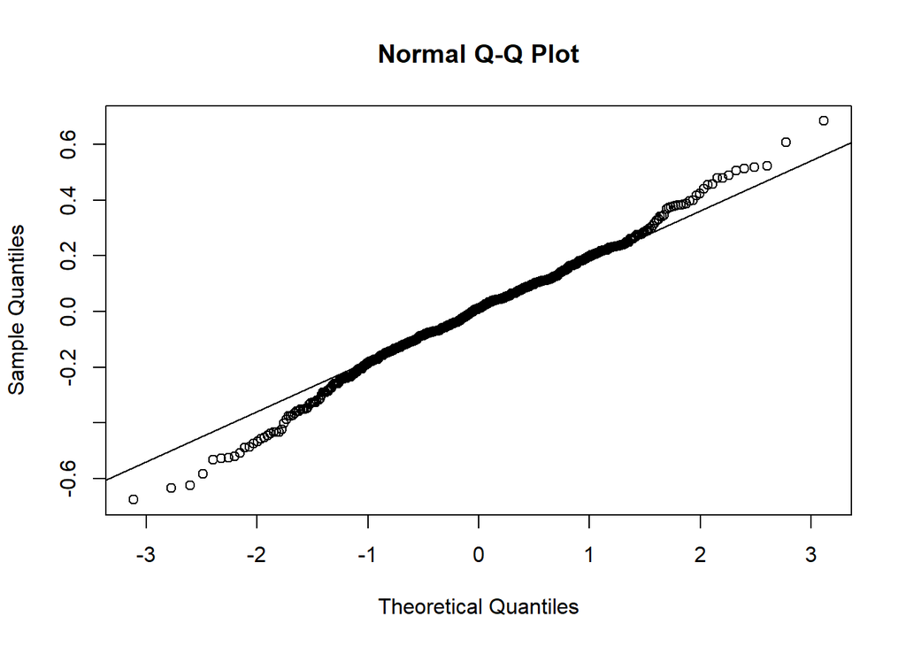

The above QQ Plot suggested a similar conclusion and it demonstrates that there’s extremes or outliers in the data set.

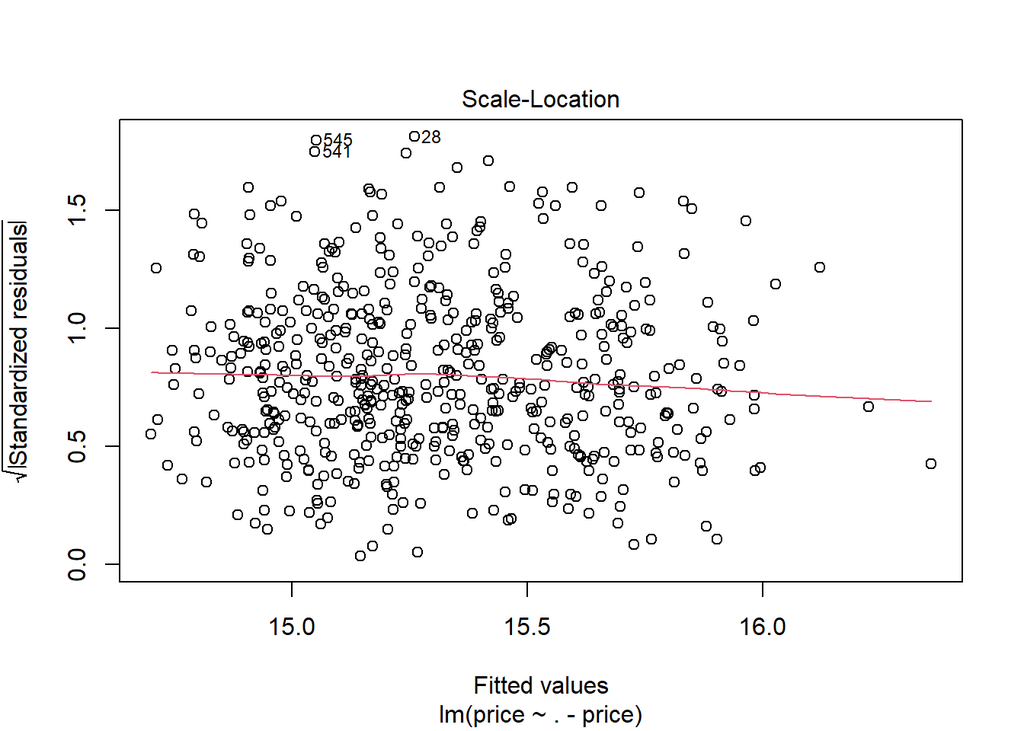